# 项目：哪一年发行的电影更受大家的喜爱

## 探索性数据分析

> **提示**在你完成数据整理和清理之后，现在可以进行探索性数据分析了。你需要计算统计值，创建可视化图表，解决你在一开始的简介部分中提出的研究问题。我们推荐你采用系统化方法。一次只探索一个变量，然后探索变量之间的关系。

### 研究问题 1 - 电影的 popularity 和 vote_count vote_average release_year runtime 之间的关系

```python
# 用这个代码框和其它代码框探索数据。请务必记得添加
#   Markdown 框，以便记录你的观察和调查结果。
# 保留所需数据列
r1list = ['popularity','runtime','vote_count','vote_average','release_year']
# 制作一个新的数据用于scater matirx显示
dfr1 = pd.DataFrame()
for i in r1list:
    dfr1[i] = df[i]
dfr1.head()
```

|  | popularity | runtime | vote_count | vote_average | release_year |
| --- | --- | --- | --- | --- | --- |
| 0 | 32.985763 | 124 | 5562 | 6.5 | 2015 |
| 1 | 28.419936 | 120 | 6185 | 7.1 | 2015 |
| 2 | 13.112507 | 119 | 2480 | 6.3 | 2015 |
| 3 | 11.173104 | 136 | 5292 | 7.5 | 2015 |
| 4 | 9.335014 | 137 | 2947 | 7.3 | 2015 |

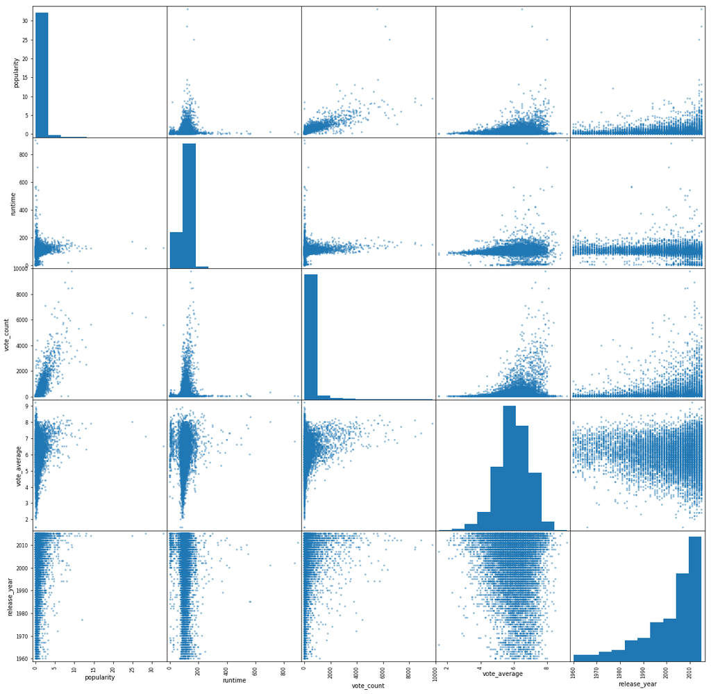

```python
# 画图观察
# scater matrix图
pd.plotting.scatter_matrix(dfr1, figsize=(20,20));
```

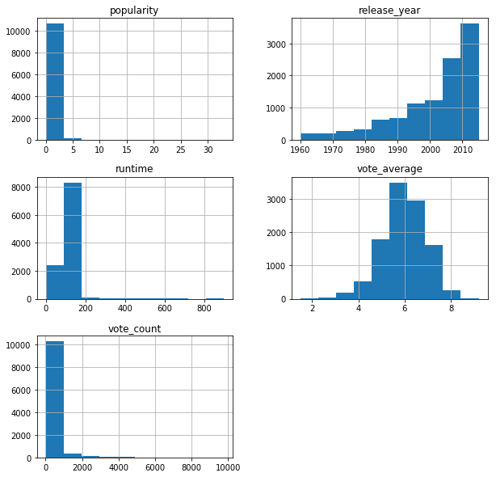

```python
# 看一下图形分布
dfr1.hist(figsize=(10,10));
```

```python
# 发现图形分布比较靠左
dfr1.describe()
```

|  | popularity | runtime | vote_count | vote_average | release_year |
| --- | --- | --- | --- | --- | --- |
| count | 10865.000000 | 10865.000000 | 10865.000000 | 10865.000000 | 10865.000000 |
| mean | 0.646446 | 102.071790 | 217.399632 | 5.975012 | 2001.321859 |
| std | 1.000231 | 31.382701 | 575.644627 | 0.935138 | 12.813260 |
| min | 0.000065 | 0.000000 | 10.000000 | 1.500000 | 1960.000000 |
| 25% | 0.207575 | 90.000000 | 17.000000 | 5.400000 | 1995.000000 |
| 50% | 0.383831 | 99.000000 | 38.000000 | 6.000000 | 2006.000000 |
| 75% | 0.713857 | 111.000000 | 146.000000 | 6.600000 | 2011.000000 |
| max | 32.985763 | 900.000000 | 9767.000000 | 9.200000 | 2015.000000 |

```python
# min到25%， 25%到50%的数值变化非常小
# runtime有空值，去除空值数据
print(len(dfr1[dfr1['runtime'] == 0]))
print(dfr1.shape)
```

```
31
(10865, 5)
```

**发现1 vote 和 popularity有关系的:**

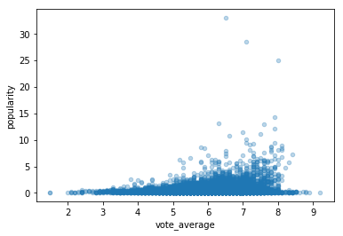

```python
# 发现1 vote 和 popularity有关系的
dfr1.plot(x='vote_average',
            y='popularity', kind='scatter', alpha=0.3);
```

**发现2 release year 和 popularity有关系的，但它们之间还有其被其它变量影响**

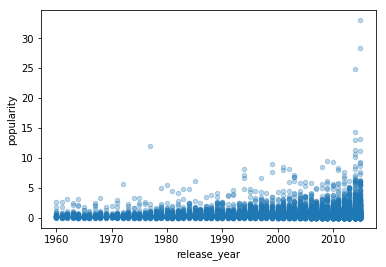

```python
# 发现2 release year 和 popularity有关系的，但它们之间还有其被其它变量影响
dfr1.plot(x='release_year',
            y='popularity', kind='scatter', alpha=0.3);
```

**发现3 runtime 和 popularity有一些关系，但是没有那么明显**

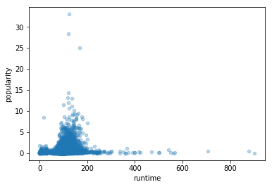

```python
# 发现3 runtime 和 popularity有一些关系，但是没有那么明显
dfr1.plot(x='runtime',
            y='popularity', kind='scatter', alpha=0.3);
```

### 研究问题 2 - 电影的 popularity 和 是否有homepage, budget_adj, revenue_adj 的关系

```python
# 去除 budget 空值
r2list = ['popularity','vote_average','budget_adj','revenue_adj', 'has_homepage']
# scater matirx 图示
dfr2 = pd.DataFrame()
for i in r2list:
    dfr2[i] = df[i]
dfr2.head()
```

|  | popularity | vote_average | budget_adj | revenue_adj | has_homepage |
| --- | --- | --- | --- | --- | --- |
| 0 | 32.985763 | 6.5 | 1.379999e+08 | 1.392446e+09 | True |
| 1 | 28.419936 | 7.1 | 1.379999e+08 | 3.481613e+08 | True |
| 2 | 13.112507 | 6.3 | 1.012000e+08 | 2.716190e+08 | True |
| 3 | 11.173104 | 7.5 | 1.839999e+08 | 1.902723e+09 | True |
| 4 | 9.335014 | 7.3 | 1.747999e+08 | 1.385749e+09 | True |

```python
dfr2.describe()
```

|  | popularity | vote_average | budget_adj | revenue_adj |
| --- | --- | --- | --- | --- |
| count | 10865.000000 | 10865.000000 | 1.086500e+04 | 1.086500e+04 |
| mean | 0.646446 | 5.975012 | 1.754989e+07 | 5.136900e+07 |
| std | 1.000231 | 0.935138 | 3.430753e+07 | 1.446383e+08 |
| min | 0.000065 | 1.500000 | 0.000000e+00 | 0.000000e+00 |
| 25% | 0.207575 | 5.400000 | 0.000000e+00 | 0.000000e+00 |
| 50% | 0.383831 | 6.000000 | 0.000000e+00 | 0.000000e+00 |
| 75% | 0.713857 | 6.600000 | 2.085325e+07 | 3.370173e+07 |
| max | 32.985763 | 9.200000 | 4.250000e+08 | 2.827124e+09 |

```python
# 根据上面的输出，budget 有很多空值，需要去掉
print(len(dfr2[dfr2['budget_adj'] == 0]))
print(dfr2.shape)

# 以及 revenue 的空值
print(len(dfr2[dfr2['revenue_adj'] == 0]))
print(dfr2.shape)
```

```
5696
(10865, 5)
6016
(10865, 5)
```

```python
mean = dfr2.groupby('has_homepage').mean()
mean
```

| has_homepage | popularity | vote_average | budget_adj | revenue_adj |
| --- | --- | --- | --- | --- |
| False | 0.515638 | 5.906886 | 1.442825e+07 | 3.670198e+07 |
| True | 0.999706 | 6.158992 | 2.598025e+07 | 9.097896e+07 |

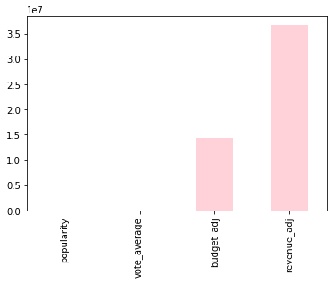

```python
# 柱形图
dfr2.groupby('has_homepage').mean().iloc[0].plot(
    kind = 'bar', alpha = 0.7, color = 'pink')
```

```python
# 上图因变量之间数量级差异大，导致变化不明显
mean_edited = mean.copy()

mean_edited['budget_adj'] = mean['budget_adj'] / 10000000
mean_edited['revenue_adj'] = mean['revenue_adj'] / 10000000
mean_edited
```

| has_homepage | popularity | vote_average | budget_adj | revenue_adj |
| --- | --- | --- | --- | --- |
| False | 0.515638 | 5.906886 | 1.442825 | 3.670198 |
| True | 0.999706 | 6.158992 | 2.598025 | 9.097896 |

```python
# 分析在有无 homepage 条件下，popularity 和 revenue 的增长变化幅度
mean_edited.iloc[1] / mean_edited.iloc[0]
```

```
popularity      1.938773
vote_average    1.042680
budget_adj      1.800652
revenue_adj     2.478857
dtype: float64
```

**研究问题2 发现有自己独立网站的电影在流行度、预算和收入上都明显高于没有独立网站的电影**

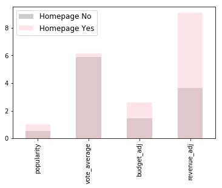

```python
# 堆叠柱状图
mean_edited.iloc[0].plot(kind = 'bar', color = 'grey', alpha = 0.4, label = "Homepage No")
mean_edited.iloc[1].plot(kind = 'bar', color = 'pink', alpha = 0.4, label = "Homepage Yes")

plt.legend(loc = 'best', fontsize = 12);
```

## 结论

### 结论

1. **结论1：**在研究问题1中，我们通过画散点图进行观察 popularity，runtime，vote，release_year 之间的关系，经过分析：电影的得分和流行度正相关；平均投票得分越高，流行度就可能越高；一部电影的运行次数在100左右时，流行度相对更高。
2. **结论2:** 在研究问题2中，我们通过画柱状图进行观察 popularity，budget，revenue，vote 和是否有 homepage 之间的关系，经过分析：一部有主页的电影相比会更受欢迎；制作主页为影片的前期增加不少的投入，但是相对而言，得到的回报更是显著；但是不太影响电影的投票数。

### 分析局限

1. 数据质量。在数据中有大量0预算，0收入的电影。猜测可能是独立电影之类的，这类数据在加到商业电影分析的工作中可能会影响结论。如果后续可以的话，可以考虑将两类电影拆分开或者用新的列区分开。可以让结论更加有针对性。
2. 分析中重点使用的是财务纬度的收入和预算，可以支撑结论。
3. 去掉异常值是为了减少偏差，所以应该根据分析的目的去掉异常值。

```python
from subprocess import call
call(['python', '-m', 'nbconvert', 'Investigate_a_Dataset.ipynb'])
```

```
255
```